# From raw trace to reported flux

Jonathan Gewirtzman

2026-09-24

This vignette walks one real chamber closure through every step between the raw 1 Hz record and the number that would be reported in a table, printing every intermediate value. Nothing here is interactive, so the document can be rebuilt with `rmarkdown::render()`.

## The closure

`example_closure()` returns `emission_stem_semirigid` from the bundled set (`?fluxqc_examples`): a tree-stem closure from the Yale-Myers Forest (Connecticut) monthly survey, spring 2021, semi-rigid sleeve chamber, ABB/LGR micro-portable UGGA logging at 1 Hz, shipped anonymized (synthetic calendar, no tree or plot identifiers) with the campaign’s clicked window and geometry:

| auxfile column | value | meaning |
| --- | --- | --- |
| `Area` | 4254.121 cm2 | surface enclosed (here a tree stem) |
| `Vtot` | 7.082698 L | chamber + tubing + analyzer cell |
| `Tcham` | 26.02 C | chamber air temperature |
| `Pcham` | 101.325 kPa | pressure |

The rows carry the campaign’s water column, so goFlux applies its water-vapour correction to the flux term exactly as in the campaign processing.

```r
library(fluxqc)
d <- example_closure()
str(d[, c("UniqueID", "POSIX.time", "t_s", "CO2dry_ppm", "CH4dry_ppb", "flag", "Etime")])
```

```
#> 'data.frame':    1207 obs. of  7 variables:
#>  $ UniqueID  : chr  "emission_stem_semirigid" "emission_stem_semirigid" "emission_stem_semirigid" "emission_stem_semirigid" ...
#>  $ POSIX.time: POSIXct, format: "2000-01-01 00:55:00" "2000-01-01 00:55:01" "2000-01-01 00:55:02" ...
#>  $ t_s       : num  -300 -299 -298 -297 -296 -295 -294 -293 -292 -291 ...
#>  $ CO2dry_ppm: num  576 576 578 577 578 ...
#>  $ CH4dry_ppb: num  2064 2063 2070 2066 2063 ...
#>  $ flag      : int  0 0 0 0 0 0 0 0 0 0 ...
#>  $ Etime     : num  -391 -390 -389 -388 -387 -386 -385 -384 -383 -382 ...
```

The data frame is the campaign’s `obs.win()` segment (the recorded `start.time` plus a shoulder on each side) with the operator’s clicked window marked `flag = 1`, exactly as `goFlux::click.peak2()` left it.

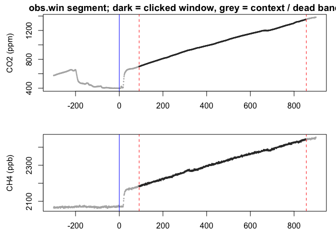

```r
w0 <- as.numeric(difftime(d$start.time_corr[1], d$start.time[1], units = "secs"))
op <- par(mfrow = c(2, 1), mar = c(3, 4.5, 1.5, 1))
plot(d$t_s, d$CO2dry_ppm, pch = 16, cex = 0.4, col = ifelse(d$flag == 1, "grey20", "grey70"),
     xlab = "", ylab = "CO2 (ppm)", main = "obs.win segment; dark = clicked window, grey = context / dead band")
abline(v = c(0, w0, w0 + d$obs.length_corr[1]), col = c("blue", "red", "red"), lty = c(1, 2, 2))
plot(d$t_s, d$CH4dry_ppb, pch = 16, cex = 0.4, col = ifelse(d$flag == 1, "grey20", "grey70"),
     xlab = "seconds since recorded start.time", ylab = "CH4 (ppb)")
abline(v = c(0, w0, w0 + d$obs.length_corr[1]), col = c("blue", "red", "red"), lty = c(1, 2, 2))
```

```r
par(op)
```

## Step 1: dead band (the clicked window)

The operator started the fitting window 91 s after the recorded closure time (chamber mixing, operator disturbance) and ended it after 765 s; that is the dead band as actually applied in the campaign. The rows with `flag == 1` are what every fit below uses.

```r
n_total <- nrow(d); n_used <- sum(d$flag == 1)
t_span  <- max(d$Etime[d$flag == 1]) - min(d$Etime[d$flag == 1])
c(n_total = n_total, n_used = n_used, window_start_s = w0, t_span_s = t_span)
```

```
#>        n_total         n_used window_start_s       t_span_s
#>           1207            770             91            765
```

## Step 2: fitted dC/dt

### 2a. Transparent linear fit

```r
w <- d[d$flag == 1, ]
fit_ch4 <- lm(CH4dry_ppb ~ Etime, data = w)
fit_co2 <- lm(CO2dry_ppm ~ Etime, data = w)
slope_ch4 <- unname(coef(fit_ch4)[2]); slope_co2 <- unname(coef(fit_co2)[2])
c(CH4_slope_ppb_per_s = slope_ch4, CH4_r2 = summary(fit_ch4)$r.squared,
  CH4_slope_SE = summary(fit_ch4)$coefficients[2, 2])
```

```
#> CH4_slope_ppb_per_s              CH4_r2        CH4_slope_SE
#>         0.336404043         0.997487259         0.000609257
```

```r
c(CO2_slope_ppm_per_s = slope_co2, CO2_r2 = summary(fit_co2)$r.squared)
```

```
#> CO2_slope_ppm_per_s              CO2_r2
#>            0.824404            0.996497
```

### 2b. goFlux linear and Hutchinson-Mosier fits

`goFlux::goFlux()` fits both the linear model (LM) and the non-linear Hutchinson-Mosier model (HM), and `goFlux::best.flux()` picks one using its default criteria. goFlux prints a progress bar; it is captured here.

```r
invisible(capture.output({
  res_ch4 <- suppressWarnings(goFlux::goFlux(d, "CH4dry_ppb"))
  res_co2 <- suppressWarnings(goFlux::goFlux(d, "CO2dry_ppm"))
}))
best_ch4 <- suppressWarnings(goFlux::best.flux(res_ch4))
best_co2 <- suppressWarnings(goFlux::best.flux(res_co2))
as.data.frame(best_ch4[, c("LM.slope", "LM.r2", "LM.SE", "HM.slope", "HM.r2", "HM.k",
                           "model", "quality.check")])
```

```
#>   LM.slope    LM.r2      LM.SE HM.slope   HM.r2        HM.k model quality.check
#> 1 0.336404 0.997484 0.00040934 0.377638 0.99839 0.000305759    HM
```

`LM.slope` is the same number as the hand-rolled `lm()` above (0.3364 ppb/s).

## Step 3: unit conversion

The gas columns are mole fractions: ppm = umol mol-1, ppb = nmol mol-1. A slope in ppb s-1 is therefore already in nmol mol-1 s-1; converting to mol mol-1 s-1 is a factor of 1e-9.

```r
slope_ch4_molfrac <- slope_ch4 * 1e-9   # mol mol-1 s-1
slope_co2_molfrac <- slope_co2 * 1e-6
c(CH4 = slope_ch4_molfrac, CO2 = slope_co2_molfrac)
```

```
#>         CH4         CO2
#> 3.36404e-10 8.24404e-07
```

## Step 4: V/A and P/RT

```r
Area_m2 <- 4254.121 / 1e4
Vtot_m3 <- 7.082698 / 1e3
T_K     <- 26.02 + 273.15
P_Pa    <- 101.325 * 1e3
R       <- 8.314
VA      <- Vtot_m3 / Area_m2          # m
PRT     <- P_Pa / (R * T_K)           # mol m-3 (molar density of air)
c(V_over_A_m = VA, P_over_RT_mol_m3 = PRT, product_mol_m2 = VA * PRT)
```

```
#>       V_over_A_m P_over_RT_mol_m3   product_mol_m2
#>         0.016649        40.736954         0.678231
```

`flux_term()` is the same product written with goFlux’s unit conventions (litres, kPa, cm2, Celsius). goFlux also multiplies by `(1 - H2O_mol)`, the mean water-vapour mole fraction of the window, to express the flux per mole of *dry* air; that is why its `flux.term` is slightly smaller than the dry product:

```r
h2o <- mean(w$H2O_ppm) / 1e6                          # mol mol-1
ft0 <- flux_term(V_L = 7.082698, P_kPa = 101.325, A_cm2 = 4254.121, T_C = 26.02)
ft  <- flux_term(V_L = 7.082698, P_kPa = 101.325, A_cm2 = 4254.121, T_C = 26.02, H2O_mol = h2o)
c(flux_term_dry = ft0, H2O_mol = h2o, flux_term_with_H2O = ft, goFlux_flux.term = best_ch4$flux.term)
```

```
#>      flux_term_dry            H2O_mol flux_term_with_H2O   goFlux_flux.term
#>         0.67823069         0.00951215         0.67177926         0.67186715
```

## Step 5: flux

```r
flux_ch4_mol   <- slope_ch4_molfrac * VA * PRT * (1 - h2o)        # mol m-2 s-1, dry-air basis
flux_ch4_nmol  <- flux_ch4_mol * 1e9                              # nmol m-2 s-1
flux_co2_umol  <- slope_co2_molfrac * VA * PRT * (1 - h2o) * 1e6  # umol m-2 s-1
c(CH4_flux_nmol_m2_s = flux_ch4_nmol, CO2_flux_umol_m2_s = flux_co2_umol)
```

```
#> CH4_flux_nmol_m2_s CO2_flux_umol_m2_s
#>           0.225989           0.553818
```

```r
# the shortcut used by goFlux: slope in ppb/s times flux.term gives nmol m-2 s-1 directly
c(shortcut = slope_ch4 * ft, goFlux_LM = best_ch4$LM.flux, goFlux_HM = best_ch4$HM.flux,
  goFlux_best = best_ch4$best.flux)
```

```
#>    shortcut   goFlux_LM   goFlux_HM goFlux_best
#>    0.225989    0.226019    0.253722    0.253722
```

## Step 6: per-measurement precision

Instrument noise is estimated from the measurement itself, not the datasheet. First differences remove the (linear) flux signal; white noise survives with variance 2 sigma^2, so sigma = SD(diff(x)) / sqrt(2).

```r
sigma_ch4 <- precision_allan(w$CH4dry_ppb)
sigma_co2 <- precision_allan(w$CO2dry_ppm)
c(sigma_CH4_ppb = sigma_ch4, sigma_CO2_ppm = sigma_co2,
  datasheet_CH4_ppb = 0.9, datasheet_CO2_ppm = 0.35,
  robust_MAD_CH4_ppb = precision_mad(w$CH4dry_ppb))
```

```
#>      sigma_CH4_ppb      sigma_CO2_ppm  datasheet_CH4_ppb  datasheet_CO2_ppm robust_MAD_CH4_ppb
#>           2.278275           0.828316           0.900000           0.350000           2.243483
```

This analyzer was about 2.5 times noisier in CH4 than its datasheet claims, which is why datasheet precision should not be used for detection limits.

## Step 7: minimum detectable flux by each method, by hand

```r
t_used <- max(w$Etime) + 1     # goFlux's t; = nb.obs at 1 Hz
mdf <- mdf_multi(flux.term = ft, t = t_used,
                 prec = 0.9,               # manufacturer, for the goFlux method
                 sigma = sigma_ch4,        # this closure (Christiansen, 2-sigma)
                 sigma.global = sigma_ch4) # a campaign median would go here (Wassmann)
t(round(mdf, 6))
```

```
#>                [,1]
#> MDF_goflux 0.000789
#> MDF_wass90 0.003286
#> MDF_wass95 0.003916
#> MDF_wass99 0.005147
#> MDF_chr90  0.009871
#> MDF_chr95  0.011767
#> MDF_chr99  0.015478
#> MDF_2sigma 0.003996
```

```r
# by hand, Table 2.5 criterion: (2 sigma / t) (V/A) (P/RT)
c(MDF_2sigma_by_hand = (2 * sigma_ch4 * 1e-9 / t_used) * VA * PRT * (1 - h2o) * 1e9)
```

```
#> MDF_2sigma_by_hand
#>         0.00399608
```

## Step 8: precision, MDF and detection flag with `flag_detection()`

`flag_detection()` does steps 6-7 for every row of a `best.flux()` table with *one* precision estimator and *one* MDF method and appends exactly six columns: `sigma_emp`, `MDF_emp`, `below_MDF_emp`, `MDF_emp_method`, `detected_emp`, `det_class_emp`. The default is the method of the companion data-processing manuscript: sigma = MAD(diff x)/sqrt(2) over the *entire* 1 Hz record of the field period (here: this closure’s whole trace, dead band included), and MDF = z sigma / t flux.term. The stated confidence is 95% two-sided, z = qnorm(0.975) = 1.96, i.e. the 2-sigma criterion (the companion manuscript itself used z = qnorm(0.95) = 1.645, its “90% confidence”). goFlux’s own columns (`MDF`, `prec`, `best.flux`, …) are left exactly as `best.flux()` produced them. Nothing is deleted; rows are flagged.

```r
rep_ch4 <- flag_detection(best_ch4, traces = d, gastype = "CH4dry_ppb",
                          precision = "mad", mdf = "wassmann", conf = 0.95)   # the defaults, spelled out
setdiff(names(rep_ch4), names(best_ch4))
```

```
#> [1] "sigma_emp"      "MDF_emp"        "below_MDF_emp"  "MDF_emp_method" "detected_emp"
#> [6] "det_class_emp"
```

```r
t(as.data.frame(rep_ch4[, c("MDF", "sigma_emp", "MDF_emp", "MDF_emp_method", "below_MDF_emp",
                            "detected_emp", "det_class_emp")]))
```

```
#>                [,1]
#> MDF            "0.0007894"
#> sigma_emp      "2.20679"
#> MDF_emp        "0.003774"
#> MDF_emp_method "wassmann | mad | 0.95"
#> below_MDF_emp  "FALSE"
#> detected_emp   "TRUE"
#> det_class_emp  "emission"
```

The multi-method comparison of step 7 is available as *extra* columns (`sigma_<precision>`, `MDF_<method>_<precision>[_<conf>]`) for cross-study reporting; they never replace the `*_emp` columns:

```r
cmp <- flag_detection(best_ch4, traces = d, gastype = "CH4dry_ppb",
                      extra = list(precision = c("allan", "mad", "datasheet"),
                                   mdf = c("goflux", "wassmann", "christiansen", "two_sigma"),
                                   conf = c(0.90, 0.95, 0.99)))
mdf_cols <- setdiff(grep("^MDF_[a-z]+_[a-z]", names(cmp), value = TRUE), "MDF_emp_method")
t(round(as.data.frame(cmp[, mdf_cols]), 6))
```

```
#>                                   [,1]
#> MDF_goflux_allan              0.001988
#> MDF_goflux_mad                0.001926
#> MDF_goflux_datasheet          0.000785
#> MDF_wassmann_allan_90         0.003270
#> MDF_wassmann_allan_95         0.003896
#> MDF_wassmann_allan_99         0.005121
#> MDF_wassmann_mad_90           0.003167
#> MDF_wassmann_mad_95           0.003774
#> MDF_wassmann_mad_99           0.004960
#> MDF_wassmann_datasheet_90     0.001292
#> MDF_wassmann_datasheet_95     0.001539
#> MDF_wassmann_datasheet_99     0.002023
#> MDF_christiansen_allan_90     0.009821
#> MDF_christiansen_allan_95     0.011707
#> MDF_christiansen_allan_99     0.015400
#> MDF_christiansen_mad_90       0.009513
#> MDF_christiansen_mad_95       0.011340
#> MDF_christiansen_mad_99       0.014917
#> MDF_christiansen_datasheet_90 0.003880
#> MDF_christiansen_datasheet_95 0.004625
#> MDF_christiansen_datasheet_99 0.006084
#> MDF_two_sigma_allan           0.003976
#> MDF_two_sigma_mad             0.003851
#> MDF_two_sigma_datasheet       0.001571
```

`MDF_goflux_datasheet` reproduces goFlux’s own `MDF` column (same formula, `t = nb.obs` instead of `max(Etime) + 1`); `MDF_wassmann_mad_95` is the default `MDF_emp`.

## Choosing precision and MDF

The default is fixed by the companion data-processing manuscript; the others are there so a report can state which one it used and readers can convert. Each method by its actual formula and origin:

**Precision estimators**

| estimator | formula | computed over | origin / use |
| --- | --- | --- | --- |
| `mad` (default) | MAD(diff x) x 1.4826 / sqrt(2) | the entire 1 Hz record of a field period (`group`) | companion manuscript (`mdf_FINAL_precision_and_detection.R`): instrument-dominated at 1 s, a constant flux cancels, robust to moves and breaths |
| `allan` | SD(diff x)/sqrt(2) | flagged rows of each closure | Allan deviation at tau = 1 s; per-closure noise |
| `rolling` | median residual SD of the quietest 5 percent of 30-sample windows | flagged rows of each closure | comparison only; biased low on white noise |
| `datasheet` | the `prec` value given to `goFlux::import.*()` | – | manufacturer 1-s specification (2.5x too optimistic here) |
| `custom` | user-supplied `sigma` | bench test | Box 2 of the guidelines paper (sealed / standard-gas run) |
| per-closure sigma (`qc_screens(noisy = ...)`) | MAD(diff x)/sqrt(2) on the closure’s flagged rows | each closure | **diagnostic, not the MDF basis**: fires `qc_noisy` when a closure is > k x noisier than its campaign sigma (disturbed closure?) |

**MDF methods** (all `= dC_min / t x flux.term`)

[output not shown]

**Which to use for what.** Campaign means, budgets and upscaling: keep every flux and report the fraction below `MDF_emp`; removing values biases means. “Is this one flux non-zero?”: the per-closure variants (`christiansen`, `two_sigma` with `allan`) use the closure’s own noise. Cross-study comparison: `extra = "all"` and report the table.

**Where each is set in the pipeline.** The `prec` argument given to `goFlux::import.*()` (or the `*_prec` columns) only feeds goFlux’s own `MDF` column and the `MDF` criterion inside `best.flux()`. fluxqc’s estimators are applied *after* `best.flux()` by `flag_detection()`, which reads the flagged traces and appends `sigma_emp`, `MDF_emp`, `below_MDF_emp`, `MDF_emp_method` (and the `extra` comparison columns if asked). goFlux’s columns are never modified. Nothing is deleted at any step: `det_class_emp` says `"below detection"`, and the row stays.

## Step 9: quality screens

Physical checks, each an independent flag (`TRUE` = fired), never a deletion. Is the CO2 tracer positive (the chamber was sealed and respiration accumulated)? Did the chamber start near ambient? Is the trace convex? Is the window long enough? With one measurement the C0 screen compares the closure to itself, so it passes trivially; in a campaign the median is taken over all closures.

```r
rep_ch4 <- qc_screens(rep_ch4, traces = d, gastype = "CH4dry_ppb", co2 = best_co2,
                      screens = list(c0 = list(k = 1.5), co2_tracer = list(min_slope = 0),
                                     convex = TRUE, min_window = list(secs = 120), noisy = list(k = 1.5)),
                      verbose = FALSE)
t(as.data.frame(rep_ch4[, c("qc_c0", "qc_c0_ratio", "qc_co2_tracer", "qc_co2_slope", "qc_convex",
                            "qc_min_window", "qc_noisy", "qc_noisy_ratio", "qc_any", "qc_note")]))
```

```
#>                [,1]
#> qc_c0          "FALSE"
#> qc_c0_ratio    "1"
#> qc_co2_tracer  "FALSE"
#> qc_co2_slope   "0.824404"
#> qc_convex      "FALSE"
#> qc_min_window  "FALSE"
#> qc_noisy       "FALSE"
#> qc_noisy_ratio "1.01663"
#> qc_any         "FALSE"
#> qc_note        NA
```

## The reported row

```r
report <- data.frame(
  UniqueID   = rep_ch4$UniqueID,
  n_obs      = rep_ch4$nb.obs,
  model      = rep_ch4$model,
  CH4_flux_nmol_m2_s = signif(rep_ch4$best.flux, 4),
  CH4_LM_SE  = signif(rep_ch4$LM.SE, 3),
  MDF_goFlux = signif(rep_ch4$MDF, 4),
  sigma_emp_ppb = signif(rep_ch4$sigma_emp, 3),
  MDF_emp    = signif(rep_ch4$MDF_emp, 3),
  MDF_emp_method = rep_ch4$MDF_emp_method,
  detected_emp = rep_ch4$detected_emp,
  class      = rep_ch4$det_class_emp,
  CO2_flux_umol_m2_s = signif(best_co2$best.flux, 4),
  qc_any     = rep_ch4$qc_any)
t(report)
```

```
#>                    [,1]
#> UniqueID           "emission_stem_semirigid"
#> n_obs              "770"
#> model              "HM"
#> CH4_flux_nmol_m2_s "0.2537"
#> CH4_LM_SE          "0.000409"
#> MDF_goFlux         "0.0007894"
#> sigma_emp_ppb      "2.21"
#> MDF_emp            "0.00377"
#> MDF_emp_method     "wassmann | mad | 0.95"
#> detected_emp       "TRUE"
#> class              "emission"
#> CO2_flux_umol_m2_s "0.6671"
#> qc_any             "FALSE"
```

The same row comes out of the one-call wrapper:

```r
invisible(capture.output(       # goFlux's progress bar is captured
  res <- suppressWarnings(process_fluxes(d, gastype = "CH4dry_ppb",
                       qc = list(c0 = TRUE, co2_tracer = TRUE, convex = TRUE, min_window = list(secs = 120)),
                       co2 = best_co2))))
res
```

```
#> fluxqc result: 1 closures, CH4dry_ppb
#>   MDF_emp: wassmann | mad | 0.95 | detected: 1 | qc_any: 0
```

```r
c(best.flux = res$fluxes$best.flux, MDF_goFlux = res$fluxes$MDF, MDF_emp = res$fluxes$MDF_emp,
  method = res$fluxes$MDF_emp_method)
```

```
#>               best.flux              MDF_goFlux                 MDF_emp
#>     "0.253722429302093"  "0.000789400050832901"   "0.00377399981197587"
#>                  method
#> "wassmann | mad | 0.95"
```

```r
all(names(best_ch4) %in% names(res$fluxes))   # goFlux columns all present, unchanged
```

```
#> [1] TRUE
```

## Summary of the numbers

| quantity | value |
| --- | --- |
| observations used | 770 |
| fit span (s) | 765 |
| CH4 slope (ppb/s) | 0.3364 |
| CH4 LM r2 | 0.9975 |
| V/A (m) | 0.016649 |
| P/RT (mol m-3) | 40.737 |
| flux.term (mol m-2) | 0.67178 |
| CH4 flux LM (nmol m-2 s-1) | 0.22602 |
| CH4 flux HM (nmol m-2 s-1) | 0.25372 |
| CH4 flux reported | 0.25372 |
| sigma CH4 (ppb, Allan, flagged rows) | 2.278 |
| sigma CH4 (ppb, MAD, whole record) = sigma_emp | 2.207 |
| MDF goFlux (datasheet, goFlux’s own column) | 0.0007894 |
| MDF Wassmann 95% (mad) = MDF_emp | 0.003774 |
| MDF Christiansen-style 95% (allan) | 0.01171 |
| MDF 2-sigma (allan) | 0.003976 |
| reported MDF_emp / method | 0.003774 wassmann \| mad \| 0.95 |
| detected | emission |
| CO2 flux (umol m-2 s-1) | 0.66707 |